# McKinsey Sales Excellence Hackathon on 20 Jan 2018

Bala Kesavan

20 January 2018

# McKinsey Sales Excellence Hackathon

The business problem is to predict loan approval, given applicant details like income, debt and demographics.

# Exploratory Data Analysis

We start with EDA and list down some of the key observations made, while the basis for the same is displayed in the calls below.

## Key observations

Of ~70K records, only 1.5% of the two-class dependent variable, ‘Approved’, are in the minority class. Correcting this imbalance with SMOTE worked better than through ROSE and downSample.  
‘DOB’ and ‘Lead_Creation_Date’ were converted from date to elapsed time/age.  
The ‘NA’ in ‘Loan_Amount’ and ‘Loan_Period’ match. Inferred as no loan taken and set to zero. Similarly for ‘EMI’ and ‘Interest_Rate’.  
The raw ‘Monthly Income’ and ‘Existing EMI’ variables are not showing sufficient discerning power. Log transform seemed to improve this and was chosen over binning, bounding etc.  
Unlabelled levels found in ‘Primary_Bank_Type’, ‘Employer_Category1’ and ‘City_Category’. Added label.  
Too many levels for ‘Employer_Code’, ‘City_Code’, ‘Customer_Existing_Primary_Bank_Code’, even after processing with drop levels. Exclude.

Chi Square tests of independence between each variable and loan approval were conducted, after data processing. Graphical tests were also performed to visualize the dependence. None of the variables analyzed could be excluded since the null hypothesis of independence have to be rejected due to the low p values. One sample bivariate analysis (Gender v/s Approved) and samples of a couple of other tests used are included below.

```r
summary(McKTrain)
```

```
##                ID           Gender            DOB
##  APPA10000905029:    1   Female:29764   11/01/82:  253
##  APPA10001412205:    1   Male  :39949   04/03/71:  183
##  APPA10004965619:    1                  03/03/71:  121
##  APPA10007179048:    1                  03/03/91:  103
##  APPA10007532038:    1                  03/03/81:   88
##  APPA10009948043:    1                  03/03/87:   83
##  (Other)        :69707                  (Other) :68882
##  Lead_Creation_Date   City_Code     City_Category    Employer_Code
##  02/09/16: 1838     C10001 :10007    :  814                 : 4018
##  22/09/16: 1629     C10002 : 8716   A:49885       COM0000002:  457
##  29/09/16: 1038     C10003 : 8666   B: 7320       COM0000003:  324
##  26/09/16: 1036     C10004 : 5843   C:11694       COM0000004:  262
##  30/09/16: 1028     C10005 : 5564                 COM0000005:  243
##  28/09/16: 1001     C10006 : 4203                 COM0000006:  195
##  (Other) :62143     (Other):26714                 (Other)   :64214
##  Employer_Category1 Employer_Category2 Monthly_Income
##   : 4018            Min.   :1.00       Min.   :       0
##  A:33336            1st Qu.:4.00       1st Qu.:    1650
##  B:18056            Median :4.00       Median :    2500
##  C:14303            Mean   :3.72       Mean   :    5622
##                     3rd Qu.:4.00       3rd Qu.:    4000
##                     Max.   :4.00       Max.   :38383838
##                     NA's   :4298
##  Customer_Existing_Primary_Bank_Code Primary_Bank_Type Contacted
##  B001   :14197                        : 9391           N:24438
##  B002   :10880                       G:20703           Y:45275
##  B003   : 9515                       P:39619
##         : 9391
##  B004   : 7070
##  B005   : 1920
##  (Other):16740
##      Source      Source_Category  Existing_EMI       Loan_Amount
##  S122   :30941   A:    3         Min.   :     0.0   Min.   :  5000
##  S133   :23877   B:29812         1st Qu.:     0.0   1st Qu.: 20000
##  S159   : 4474   C:11374         Median :     0.0   Median : 30000
##  S143   : 3480   D:  497         Mean   :   360.9   Mean   : 39430
##  S127   : 1546   E: 1050         3rd Qu.:   350.0   3rd Qu.: 50000
##  S137   : 1400   F:  459         Max.   :545436.5   Max.   :300000
##  (Other): 3995   G:26518         NA's   :51         NA's   :27709
##   Loan_Period    Interest_Rate        EMI             Var1
##  Min.   :1.000   Min.   :11.99   Min.   :  118   Min.   : 0.000
##  1st Qu.:3.000   1st Qu.:15.25   1st Qu.:  649   1st Qu.: 0.000
##  Median :4.000   Median :18.00   Median :  941   Median : 2.000
##  Mean   :3.891   Mean   :19.21   Mean   : 1101   Mean   : 3.948
##  3rd Qu.:5.000   3rd Qu.:20.00   3rd Qu.: 1295   3rd Qu.: 7.000
##  Max.   :6.000   Max.   :37.00   Max.   :13556   Max.   :10.000
##  NA's   :27709   NA's   :47437   NA's   :47437
##     Approved
##  Min.   :0.00000
##  1st Qu.:0.00000
##  Median :0.00000
##  Mean   :0.01463
##  3rd Qu.:0.00000
##  Max.   :1.00000
##
```

```r
str(McKTrain)
```

```
## 'data.frame':    69713 obs. of  22 variables:
##  $ ID                                 : Factor w/ 69713 levels "APPA10000905029",..: 7809 9062 12525 15528 17798 24053 28923 29974 33036 36522 ...
##  $ Gender                             : Factor w/ 2 levels "Female","Male": 1 2 2 2 2 1 2 1 2 1 ...
##  $ DOB                                : Factor w/ 10760 levels "","01/01/53",..: 8114 2595 3643 10258 6633 8267 9654 4343 860 4722 ...
##  $ Lead_Creation_Date                 : Factor w/ 92 levels "01/07/16","01/08/16",..: 43 10 55 25 58 1 4 7 4 4 ...
##  $ City_Code                          : Factor w/ 679 levels "","C10001","C10002",..: 2 4 126 478 3 403 23 4 4 15 ...
##  $ City_Category                      : Factor w/ 4 levels "","A","B","C": 2 2 4 4 2 4 3 2 2 3 ...
##  $ Employer_Code                      : Factor w/ 36618 levels "","COM0000002",..: 29286 2 5128 4081 1777 7346 21787 14047 9675 28240 ...
##  $ Employer_Category1                 : Factor w/ 4 levels "","A","B","C": 2 4 4 2 2 2 3 2 2 2 ...
##  $ Employer_Category2                 : int  4 1 4 4 4 4 4 4 4 4 ...
##  $ Monthly_Income                     : num  2000 3500 2250 3500 10000 7000 7500 3000 2500 2500 ...
##  $ Customer_Existing_Primary_Bank_Code: Factor w/ 58 levels "","B001","B002",..: 2 3 4 4 2 15 4 7 18 1 ...
##  $ Primary_Bank_Type                  : Factor w/ 3 levels "","G","P": 3 3 2 2 3 3 2 3 2 1 ...
##  $ Contacted                          : Factor w/ 2 levels "N","Y": 1 2 2 2 2 1 2 2 2 1 ...
##  $ Source                             : Factor w/ 29 levels "S122","S123",..: 1 1 16 16 8 7 1 7 7 1 ...
##  $ Source_Category                    : Factor w/ 7 levels "A","B","C","D",..: 7 7 2 2 2 2 3 2 2 2 ...
##  $ Existing_EMI                       : num  0 0 0 0 2500 0 0 0 0 0 ...
##  $ Loan_Amount                        : int  NA 20000 45000 92000 50000 NA 130000 30000 66000 NA ...
##  $ Loan_Period                        : int  NA 2 4 5 2 NA 5 3 5 NA ...
##  $ Interest_Rate                      : num  NA 13.2 NA NA NA ...
##  $ EMI                                : int  NA 953 NA NA NA NA 3082 1088 1749 NA ...
##  $ Var1                               : int  0 10 0 7 10 0 10 0 7 0 ...
##  $ Approved                           : int  0 0 0 0 0 0 0 0 0 0 ...
```

```r
#Sample test for finding patterns in 'NA' (this one shows why the following situtaion was inferred as no loan/ zeroes)
sum((is.na(McKTrain$Interest_Rate)) & (is.na(McKTrain$EMI)))
```

```
## [1] 47437
```

# Data processing

Data processing/ munging has been done using external functions listed at the very end of this file.

```r
trainData_WIP <- McK_pre_SMOTE_common(McKTrain)
trainData_WIP <- McK_pre_proc_train_only(trainData_WIP)
#fixing imbalanced classes in 2 class dependent variable
library(DMwR)
set.seed(76)
McKTrain_SMOTE <- SMOTE(Approved~., data= trainData_WIP)
trainData_WIP <- McK_pre_proc_common(McKTrain_SMOTE)

testData_WIP <- McK_pre_SMOTE_common(McKTest)
testData_WIP <- McK_pre_proc_common(testData_WIP)
```

## Sample EDA tests on processed data

```r
library(dplyr)
library(ggplot2)
library(caret)
#Bivariate analysis: Gender v/s Approved
chisq.test(trainData_WIP$Gender, trainData_WIP$Approved)
```

```
##
##  Pearson's Chi-squared test with Yates' continuity correction
##
## data:  trainData_WIP$Gender and trainData_WIP$Approved
## X-squared = 145.15, df = 1, p-value < 2.2e-16
```

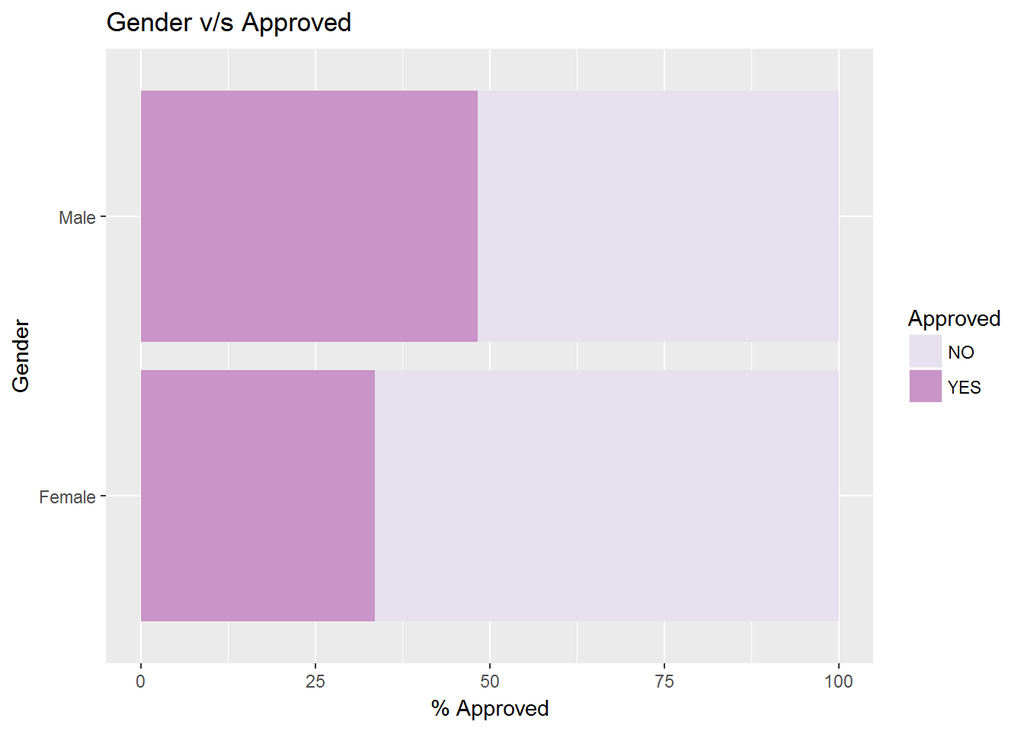

```r
trainData_WIP %>% group_by(Gender, Approved) %>%
  summarise(count=n()) %>%
  mutate(perc=count/sum(count)) %>%
  ggplot(aes(x=Gender, y=perc*100, fill=Approved)) +
  geom_bar(stat="identity") +
  geom_col(show.legend = T, ) +
  labs(title="Gender v/s Approved", y="% Approved") +
  scale_fill_brewer(palette="PuRd") +
  coord_flip()
```

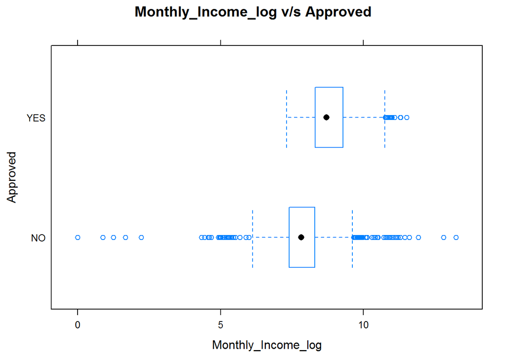

```r
#Univariate analysis: Monthly_Income_log v/s Approved
bwplot(Approved~Monthly_Income_log, data=trainData_WIP,
       xlab = 'Monthly_Income_log', ylab = 'Approved', main= 'Monthly_Income_log v/s Approved')
```

# Model training and evaluation

To pick good predictors out of the 18 remaining independent variables, a random forest model was fit first. From variable importance results of this model, these 9 predictors are picked: ‘Monthly_Income_log’, ‘Lead_Age’, ‘Existing_EMI_log’, ‘App_Age’, “Loan_Amount”, ‘Var1’, ‘Loan_Period’, ‘Interest_Rate’, ‘EMI’.  
7 new models with different algorithms were fitted. No suprises in the Kaggle favorite, XGBoost, performing best.

## Predictor selection using random forest

```r
#predictor selection using with RF
Control <- trainControl(
  #method = 'repeatedcv', number = 10, repeats = 3,
  classProbs = TRUE, summaryFunction = twoClassSummary)
model_RF_SMOTE <- train(Approved~., data = trainData_WIP[,-which(names(trainData_WIP) %in% c('ID'))],
                                 method = 'rf', trControl = Control, metric = 'ROC')
```

## Viewing and picking top predictors

```r
library(caret)
varImp(model_RF_SMOTE, scale = FALSE)
```

```
## rf variable importance
##
##   only 20 most important variables shown (out of 49)
##
##                     Overall
## Monthly_Income_log  1087.02
## Lead_Age             615.76
## Existing_EMI_log     296.09
## App_Age              289.21
## Loan_Amount          176.65
## Var110               161.01
## Loan_Period          129.18
## Interest_Rate         96.63
## EMI                   95.77
## SourceS133            39.54
## Primary_Bank_TypeP    37.05
## SourceS134            35.74
## Var17                 32.88
## Employer_Category1A   30.45
## GenderMale            27.62
## Primary_Bank_TypeG    26.97
## Employer_Category1B   26.58
## Employer_Category24   24.85
## SourceS137            24.74
## Source_CategoryB      24.64
```

```r
keeps <- c('Monthly_Income_log', 'Lead_Age', 'Existing_EMI_log', 'App_Age', "Loan_Amount", 'Var1',
           'Loan_Period', 'Interest_Rate', 'EMI', 'Approved', 'ID') #picking predictor columns
trainData_WIP_Trimmed <- trainData_WIP[,names(trainData_WIP) %in% keeps] #keeping above columns
```

## Model training

Caret’s ability to optimize parameters is leveraged in training models with 7 different algorithms.

```r
Control <- trainControl(method = 'cv', number = 10, classProbs = TRUE, summaryFunction = twoClassSummary)

#training with XGBoost
set.seed(7)
model_xgbTree_SMOTE_Trimmed <- train(Approved~., data = trainData_WIP_Trimmed[,-which(names(trainData_WIP_Trimmed) %in% c('ID'))],
                                  method="xgbTree", trControl=Control, verbose=FALSE, trace=FALSE)

#training with Bagged AdaBoost
set.seed(7)
model_BaggedAdaBoost_SMOTE_Trimmed <- train(Approved~., data = trainData_WIP_Trimmed[,-which(names(trainData_WIP_Trimmed) %in% c('ID'))],
                                     method="AdaBag", trControl=Control, verbose=FALSE, trace=FALSE)

#training with 'Multi-Layer Perceptron, multiple layers'
set.seed(7)
model_MPML_SMOTE_Trimmed <- train(Approved~., data = trainData_WIP_Trimmed[,-which(names(trainData_WIP_Trimmed) %in% c('ID'))],
                                            method="mlpWeightDecayML", trControl=Control, verbose=FALSE, trace=FALSE)

#training with RF
set.seed(7)
model_RF_SMOTE_Trimmed <- train(Approved~., data = trainData_WIP_Trimmed[,-which(names(trainData_WIP_Trimmed) %in% c('ID'))],
                        method = 'rf', trControl = Control, metric = 'ROC')

#training with GBM
set.seed(7)
model_GBM_SMOTE_Trimmed <- train(Approved~., data = trainData_WIP_Trimmed[,-which(names(trainData_WIP_Trimmed) %in% c('ID'))],
                  method="gbm", trControl=Control, verbose=FALSE)

#training with GLM
set.seed(7)
model_GLM_SMOTE_Trimmed <- train(Approved~., data = trainData_WIP_Trimmed[,-which(names(trainData_WIP_Trimmed) %in% c('ID'))],
                  method="glm", trControl=Control)


#training with NNET
set.seed(7)
model_NNET_SMOTE_Trimmed <- train(Approved~., data = trainData_WIP_Trimmed[,-which(names(trainData_WIP_Trimmed) %in% c('ID'))],
                   method="nnet", trControl=Control, verbose=FALSE, trace=FALSE)
```

# Trained models, performance summary

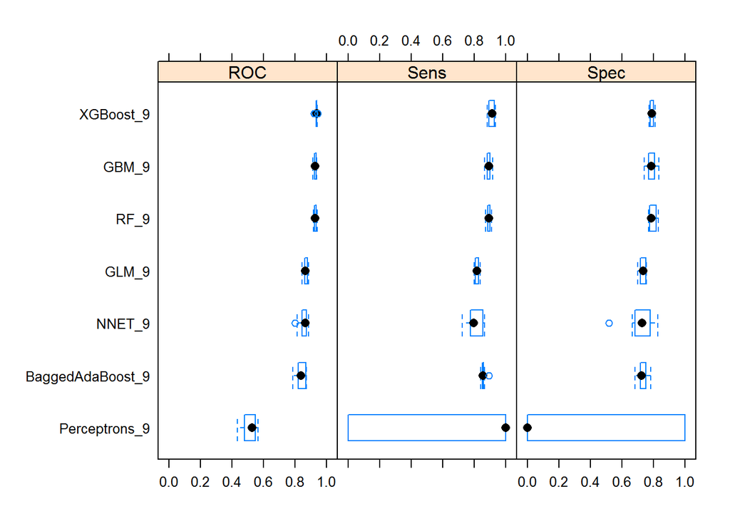

```r
#collect resamples for models with top 9 predictors
results_9 <- resamples(list(XGBoost_9=model_xgbTree_SMOTE_Trimmed, BaggedAdaBoost_9=model_BaggedAdaBoost_SMOTE_Trimmed,
                            Perceptrons_9 = model_MPML_SMOTE_Trimmed, NNET_9=model_NNET_SMOTE_Trimmed, GLM_9= model_GLM_SMOTE_Trimmed,
                            GBM_9 = model_GBM_SMOTE_Trimmed, RF_9 = model_RF_SMOTE_Trimmed))
# summarize the performance
bwplot(results_9)
```

```r
summary(results_9)
```

```
##
## Call:
## summary.resamples(object = results_9)
##
## Models: XGBoost_9, BaggedAdaBoost_9, Perceptrons_9, NNET_9, GLM_9, GBM_9, RF_9
## Number of resamples: 10
##
## ROC
##                       Min.   1st Qu.    Median      Mean   3rd Qu.
## XGBoost_9        0.9203912 0.9347907 0.9387655 0.9359886 0.9390259
## BaggedAdaBoost_9 0.7857955 0.8222258 0.8378949 0.8394788 0.8693872
## Perceptrons_9    0.4343642 0.4848035 0.5298403 0.5137784 0.5481706
## NNET_9           0.8004734 0.8446211 0.8666378 0.8548535 0.8724950
## GLM_9            0.8454761 0.8644672 0.8676390 0.8699210 0.8782399
## GBM_9            0.9132826 0.9245212 0.9289196 0.9281759 0.9335142
## RF_9             0.9176198 0.9255515 0.9289055 0.9303453 0.9366309
##                       Max. NA's
## XGBoost_9        0.9466952    0
## BaggedAdaBoost_9 0.8747477    0
## Perceptrons_9    0.5651712    0
## NNET_9           0.8875112    0
## GLM_9            0.8873831    0
## GBM_9            0.9380367    0
## RF_9             0.9416090    0
##
## Sens
##                       Min.   1st Qu.    Median      Mean   3rd Qu.
## XGBoost_9        0.8848039 0.8933824 0.9129902 0.9100490 0.9246324
## BaggedAdaBoost_9 0.8406863 0.8504902 0.8553922 0.8571078 0.8596814
## Perceptrons_9    0.0000000 0.0000000 1.0000000 0.6000000 1.0000000
## NNET_9           0.7230392 0.7787990 0.7953431 0.8066176 0.8517157
## GLM_9            0.7990196 0.8100490 0.8161765 0.8181373 0.8272059
## GBM_9            0.8651961 0.8866422 0.8933824 0.8931373 0.9013480
## RF_9             0.8725490 0.8872549 0.8933824 0.8926471 0.8995098
##                       Max. NA's
## XGBoost_9        0.9338235    0
## BaggedAdaBoost_9 0.8921569    0
## Perceptrons_9    1.0000000    0
## NNET_9           0.8676471    0
## GLM_9            0.8382353    0
## GBM_9            0.9166667    0
## RF_9             0.9117647    0
##
## Spec
##                       Min.   1st Qu.    Median      Mean   3rd Qu.
## XGBoost_9        0.7712418 0.7794118 0.7892157 0.7892157 0.7982026
## BaggedAdaBoost_9 0.6830065 0.7165033 0.7222222 0.7290850 0.7475490
## Perceptrons_9    0.0000000 0.0000000 0.0000000 0.4000000 1.0000000
## NNET_9           0.5163399 0.6846405 0.7287582 0.7186275 0.7777778
## GLM_9            0.6993464 0.7165033 0.7336601 0.7310458 0.7508170
## GBM_9            0.7418301 0.7704248 0.7859477 0.7866013 0.8071895
## RF_9             0.7679739 0.7769608 0.7875817 0.7944444 0.8129085
##                       Max. NA's
## XGBoost_9        0.8104575    0
## BaggedAdaBoost_9 0.7810458    0
## Perceptrons_9    1.0000000    0
## NNET_9           0.8267974    0
## GLM_9            0.7549020    0
## GBM_9            0.8333333    0
## RF_9             0.8300654    0
```

## XGBoost’s performance

Being the best performing model, the XGBoost model is examined in detail below. The exhaustive tuning performed by caret is shown.

```r
#taking a better look at the XGBoost model
model_xgbTree_SMOTE_Trimmed
```

```
## eXtreme Gradient Boosting
##
## 7140 samples
##    9 predictor
##    2 classes: 'NO', 'YES'
##
## No pre-processing
## Resampling: Cross-Validated (10 fold)
## Summary of sample sizes: 6426, 6426, 6426, 6426, 6426, 6426, ...
## Resampling results across tuning parameters:
##
##   eta  max_depth  colsample_bytree  subsample  nrounds  ROC
##   0.3  1          0.6               0.50        50      0.9059757
##   0.3  1          0.6               0.50       100      0.9130847
##   0.3  1          0.6               0.50       150      0.9164124
##   0.3  1          0.6               0.75        50      0.9050594
##   0.3  1          0.6               0.75       100      0.9124900
##   0.3  1          0.6               0.75       150      0.9158853
##   0.3  1          0.6               1.00        50      0.9042436
##   0.3  1          0.6               1.00       100      0.9117475
##   0.3  1          0.6               1.00       150      0.9152525
##   0.3  1          0.8               0.50        50      0.9053801
##   0.3  1          0.8               0.50       100      0.9140499
##   0.3  1          0.8               0.50       150      0.9177436
##   0.3  1          0.8               0.75        50      0.9058079
##   0.3  1          0.8               0.75       100      0.9135281
##   0.3  1          0.8               0.75       150      0.9168989
##   0.3  1          0.8               1.00        50      0.9042151
##   0.3  1          0.8               1.00       100      0.9122225
##   0.3  1          0.8               1.00       150      0.9152838
##   0.3  2          0.6               0.50        50      0.9256184
##   0.3  2          0.6               0.50       100      0.9315628
##   0.3  2          0.6               0.50       150      0.9335464
##   0.3  2          0.6               0.75        50      0.9267850
##   0.3  2          0.6               0.75       100      0.9338672
##   0.3  2          0.6               0.75       150      0.9350843
##   0.3  2          0.6               1.00        50      0.9256344
##   0.3  2          0.6               1.00       100      0.9336077
##   0.3  2          0.6               1.00       150      0.9352889
##   0.3  2          0.8               0.50        50      0.9266128
```

[output cut: 182 more lines]

```
##   0.8933824  0.7944444
##   0.9061275  0.7911765
##   0.9009804  0.7931373
##   0.8990196  0.7915033
##   0.9071078  0.7872549
##   0.9031863  0.7934641
##   0.9004902  0.7918301
##
## Tuning parameter 'gamma' was held constant at a value of 0
##
## Tuning parameter 'min_child_weight' was held constant at a value of 1
## ROC was used to select the optimal model using  the largest value.
## The final values used for the model were nrounds = 150, max_depth = 2,
##  eta = 0.4, gamma = 0, colsample_bytree = 0.6, min_child_weight = 1
##  and subsample = 1.
```

## Predictions

Code used to make and save predictions to submit to the hackathon.

```r
XGB_results <- predict(model_xgbTree_SMOTE_Trimmed, newdata = testData_WIP)
submission <- cbind(as.character(McKTest$ID), XGB_results)
submission <- as.data.frame(submission)
names(submission) <- c('ID', 'Approved')
levels(submission$Approved)[levels(submission$Approved) == 1] <- 0
levels(submission$Approved)[levels(submission$Approved) == 2] <- 1
write.csv(submission, file='submission_XGB.csv', row.names = FALSE)

#similarly for all other models
```

## Using functions

To maintain high reuse and repeatability, data pre-processing/ munging has been placed into functions.

```r
McK_pre_SMOTE_common <- function (McKSalesData) {
  McKSalesDataTrimmed <- McKSalesData
  #dropping less informative columns
  drops <- c('Employer_Code', 'City_Code', 'Customer_Existing_Primary_Bank_Code') #picking less informative columns
  McKSalesDataTrimmed <- McKSalesDataTrimmed[,!names(McKSalesDataTrimmed) %in% drops] #dropping above columns

  McKSalesDataTrimmed$Employer_Category2[is.na(McKSalesDataTrimmed$Employer_Category2)] <- 'EC2' #fixing NA in a variable before making it categorical

  #converting appropriate columns to categorical
  change_to_fact <- c('Var1','Employer_Category2')
  McKSalesDataTrimmed[change_to_fact] <- lapply(McKSalesDataTrimmed[change_to_fact], factor)

  McKSalesDataTrimmed
}

McK_pre_proc_train_only <- function (McKSalesData) {
  McKSalesDataTrimmed <- McKSalesData
  #converting appropriate columns to categorical
  change_to_fact <- c('Approved')
  McKSalesDataTrimmed[change_to_fact] <- lapply(McKSalesDataTrimmed[change_to_fact], factor)

  levels(McKSalesDataTrimmed$Approved)[levels(McKSalesDataTrimmed$Approved) == '0'] <- 'NO'
  levels(McKSalesDataTrimmed$Approved)[levels(McKSalesDataTrimmed$Approved) == '1'] <- 'YES'


  McKSalesDataTrimmed
}

McK_pre_proc_test_only <- function (McKSalesData) {
  McKSalesData$Existing_EMI[is.na(McKSalesData$Existing_EMI)] <- "" ## dummy value for NA rows in test data
  McKSalesData
}

calc_age <- function(birthDate, refDate = Sys.Date()) {           #function that calculates elapsed time since a given date
  #to current/ system date (modified code found on github)
  require(lubridate)
  duration <- as.duration(interval(birthDate, refDate))
  cbind((duration/(60*60*24*365)), (duration/(60*60*24)))
}

McK_pre_proc_common <- function (McKSalesData) {
  McKSalesDataTrimmed <- McKSalesData
  #Unlabelled levels fix
  levels(McKSalesDataTrimmed$Primary_Bank_Type)[levels(McKSalesDataTrimmed$Primary_Bank_Type) == ''] <- 'PBT'
  levels(McKSalesDataTrimmed$Employer_Category1)[levels(McKSalesDataTrimmed$Employer_Category1) == ''] <- 'EC1'
  levels(McKSalesDataTrimmed$City_Category)[levels(McKSalesDataTrimmed$City_Category) == ''] <- 'CC'


  #fixes for missing data in continuous variable columns
  McKSalesDataTrimmed$Existing_EMI[is.na(McKSalesDataTrimmed$Existing_EMI)] <- 0
  McKSalesDataTrimmed$Loan_Amount[is.na(McKSalesDataTrimmed$Loan_Amount)] <- 0
  McKSalesDataTrimmed$Loan_Period[is.na(McKSalesDataTrimmed$Loan_Period)] <- 0
  McKSalesDataTrimmed$Interest_Rate[is.na(McKSalesDataTrimmed$Interest_Rate)] <- 0
  McKSalesDataTrimmed$EMI[is.na(McKSalesDataTrimmed$EMI)] <- 0

  #transforming continous variables (other transformations like upper bound, exp and sqrt tested and rejected)
  #the +1 is because of zeros in the data and we need to prevent the invalid log of zero calculation
  McKSalesDataTrimmed$Monthly_Income_log <- log(McKSalesDataTrimmed$Monthly_Income+1)
  McKSalesDataTrimmed$Existing_EMI_log <- log(McKSalesDataTrimmed$Existing_EMI+1)
  drops_trfm <- c('Existing_EMI', 'Monthly_Income')
  McKSalesDataTrimmed <- McKSalesDataTrimmed[,!names(McKSalesDataTrimmed) %in% drops_trfm] #dropping the original/ untransformed columns

  #converting dates to ages
  McKSalesDataTrimmed$Lead_Age <- (calc_age(as.Date(McKSalesDataTrimmed$Lead_Creation_Date, format = '%d/%m/%y')))[,2]
  McKSalesDataTrimmed <- McKSalesDataTrimmed[,!names(McKSalesDataTrimmed) %in% c("Lead_Creation_Date")] #dropping 'Lead_Creation_Date' column
  #several ages are negative (POSIX standards issue with converting yy to YYYY format) and need to be fixed.
  levels(McKSalesDataTrimmed$DOB)[levels(McKSalesDataTrimmed$DOB) == ''] <- '01/01/2000' ## dummy value for blank rows in data
  McKSalesDataTrimmed$App_Age <- (calc_age(as.Date(McKSalesDataTrimmed$DOB, format = '%d/%m/%y')))[,1]
  neg_age_index <- as.Date(McKSalesDataTrimmed$DOB, format = '%d/%m/%y') > Sys.Date()
  McKSalesDataTrimmed$App_Age[neg_age_index] <- McKSalesDataTrimmed$App_Age[neg_age_index]+100
  McKSalesDataTrimmed <- McKSalesDataTrimmed[,!names(McKSalesDataTrimmed) %in% c("DOB")] #dropping 'DOB' column


  #dropping unused levels in categorical variables
  McKSalesDataTrimmed$Source <- droplevels((McKSalesDataTrimmed$Source))

  McKSalesDataTrimmed

}
```